# Cyfrowe przetwarzanie sygnałów i obrazów

**Autorki:** Barbara Parzonka 263955, Joanna Zoglowek 264452  
**Ćwiczenie 6.**

Zaobserwuj działanie następujących przekształceń punktowych na przykładowych obrazach:  
a) Mnożenie obrazu przez stałą T(r) = c · r, gdzie c jest stałą.  
Obrazy: chest_xray.tif, pollen-dark.tif, spectrum.tif.  
b) Transformację logarytmiczną  
T(r) = c · log (1 + r).  
Obraz: spectrum.tif.  
c) Zmianę dynamiki skali szarości (kontrastu). Możesz zastosować transformację o postaci T(r) = 1/(1 + (m/r)^e) , gdzie m i e są ustalonymi parametrami przekształcenia (np. m = 0,45, e = 8). Wykreśl T(r), by lepiej uwidocznić wpływ T na kontrast obrazu wyjściowego. Przeprowadź eksperymenty z różnymi wartościami parametrów m i e.  
Obrazy: chest_xray.tif, einstein-low-contrast.tif, pollen-lowcontrast.tif.  
d) Korekcję gamma, zdefiniowaną jako s = c · r^γ , gdzie c > 0 i γ > 0 są stałymi we wzorze przekształcenia.  
Obraz: aerial_view.tif

**Opis dla notebook jupyter**  
Aby pokazać działanie systemu należy: Kliknąć Run->Run All Cells  
Dla każdego obrazu i każdej metody znajduje się osobny slider, któy umożliwia dostosowanie stałej i eksperymentalne przetestowanie wartości. Domyślne wartości, z którymi się uruchamia program zostały ustawione metodą eksperymentalną przez nas w oparciu o materiały z wykładu  
**Opis dla html** Z powodu problemów z przekonwertowaniem notatnika do dynamicznej wersji strony przygotowano wersję z ustawionymi stałymi wartościami opisanymi w **"Opis dla notebook jupyter"**.

```python
%run functions.ipynb
data_path='../data/'
image_extension=".tif"
from ipywidgets import interact
import ipywidgets as widgets
```

**Transformacja punktowa - mnożenie przez stałą**  
Mnożenie przez stałą zwiększa kontrast. Wszytskie jasne punkty zbiegają do bieli, a ciemne do czerni

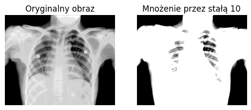

```python
image_path=data_path+"chest-xray"+image_extension
multiplication(image_path=image_path, c=10)
```

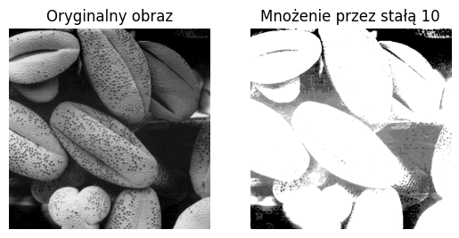

```python
image_path=data_path+"pollen-dark"+image_extension
multiplication(image_path, c=10)
```

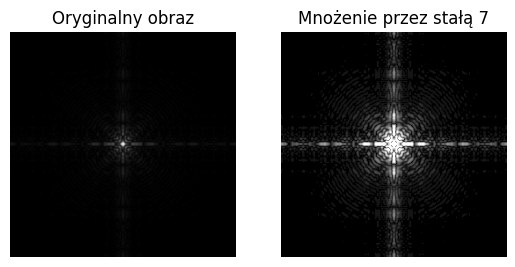

```python
image_path=data_path+"spectrum"+image_extension
multiplication(image_path, 7)
```

**Transformatcja logarytmiczna**  
Pozwala na wykrycie niewidocznych do tej pory szczegółów.

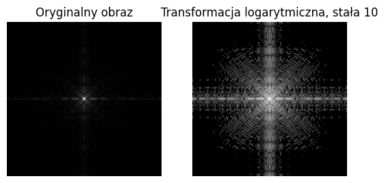

```python
logarithmical(image_path, 10)
```

**Transformatcja kontrastu**  
Pozwala na wykrycie niewidocznych do tej pory szczegółów.

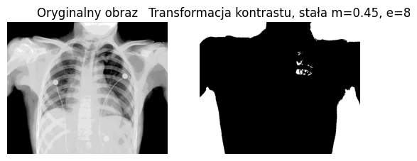

```python
image_path=data_path+"chest-xray"+image_extension
change_contrast(image_path=image_path, m=0.45, e=8)
```

[figure not shown]

```python
image_path=data_path+"einstein-low-contrast"+image_extension
change_contrast(image_path=image_path, m=0.45, e=8)
```

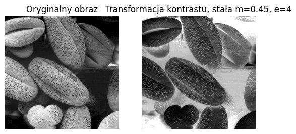

```python
image_path=data_path+"pollen-lowcontrast"+image_extension
change_contrast(image_path=image_path, m=0.45, e=4)
```

**Transformatcja gamma**  
Pozwala na zwiększenie kontrastu przy jednoczesnym uwypukleniu szczegółów.

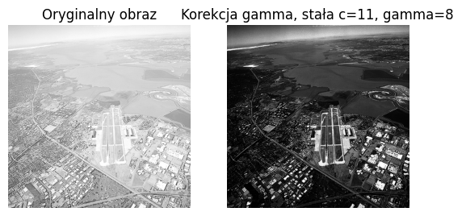

```python
image_path=data_path+"aerial_view"+image_extension
gamma_corection(image_path=image_path, c=11, gamma=8)
```